# Top climate scientists are sceptical that nations will rein in global warming

# Top climate scientists are sceptical that nations will rein in global warming

A *Nature* survey reveals that many authors of the latest IPCC climate-science report are anxious about the future and expect to see catastrophic changes in their lifetimes.

By

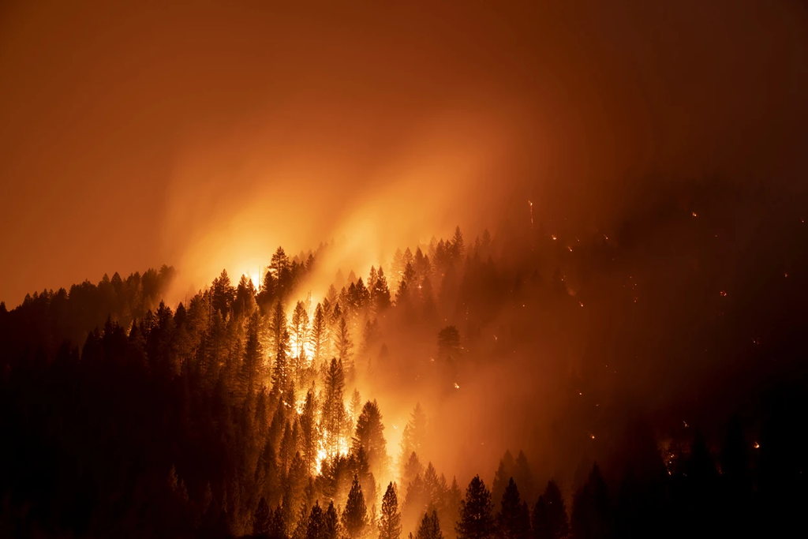

The Dixie wildfire in California this year was the second-largest in state history, and was fuelled by high temperatures and drought. Credit: Eric Thayer/Bloomberg/Getty

As a leading climate scientist, Paola Arias doesn’t need to look far to see the world changing. Shifting rain patterns threaten water supplies in her home city of Medellín, Colombia, while rising sea levels endanger the country’s coastline. She isn’t confident that international leaders will slow global warming or that her own government can handle the expected fallout, such as mass migrations and civil unrest over rising inequality. With such an uncertain future, she thought hard several years ago about whether to have children.

“My answer was no,” says Arias, a researcher at the University of Antioquia in Medellín, who was one of the 234 scientists who wrote a [climate-science report](https://www.nature.com/articles/d41586-021-02179-1) published by the Intergovernmental Panel on Climate Change (IPCC) in August (see go.nature.com/3pjupro). That assessment, which makes clear that the world is running out of time to avoid the most severe impacts of climate change, will figure prominently in climate negotiations over the next two weeks at the COP26 meeting in Glasgow, UK.

Many other leading climate researchers share Arias’s concerns about the future. *Nature* conducted an anonymous survey of the 233 living IPCC authors last month and received responses from 92 scientists — about 40% of the group. Their answers suggest strong scepticism that governments will markedly slow the pace of global warming, despite political promises made by international leaders as part of the 2015 Paris climate agreement.

Six in ten of the respondents said that they expect the world to warm by at least 3 °C by the end of the century, compared with what conditions were like before the Industrial Revolution. That is far beyond the Paris agreement’s goal to limit warming to 1.5–2 °C.

[figure not shown]

Source: *Nature* analysis

Most of the survey’s respondents — 88% — said they think global warming constitutes a ‘crisis’, and nearly as many said they expect to see catastrophic impacts of climate change in their lifetimes. Just under half said that global warming has caused them to reconsider major life decisions, such as where to live and whether to have children. More than 60% said that they experience anxiety, grief or other distress because of concerns over climate change.

[figure not shown]

Source: *Nature* analysis

For Arias, who frequently sees the impacts of political instability out of her office window as immigrants from strife-torn Venezuela wander the streets seeking food and shelter, the choice about children came naturally. She says many friends and colleagues have arrived at the same conclusion. “I’m not saying that that is a decision that everyone should make,” she says, “but it’s not something I am struggling with much any more.”

[figure not shown]

Source: *Nature* analysis

The pessimism expressed by some IPCC panellists underscores the vast gulf between hopes and expectations for the climate summit that began this week in Glasgow. In advance of the meeting, the United States, the European Union, China and others have announced new plans to curb greenhouse-gas emissions, although scientific analyses suggest those plans still fall well short of the Paris goals. Over the next two weeks, countries will formalize — and perhaps even strengthen — those commitments. But making them a reality will require as-yet-[unprecedented political mobilization at the national level once leaders return home](https://www.nature.com/immersive/d41586-021-02815-w/index.html).

[figure not shown]

Source: *Nature* analysis

“Right now, governments are just at the stage of providing green promises, but so far we have not seen any actions to curb greenhouse-gas emissions,” says Mouhamadou Bamba Sylla, an IPCC author and climate modeller at the African Institute for Mathematical Sciences in Kigali, Rwanda. Sylla says his home country of Senegal has gone through all the motions and developed adaptation plans for a warming climate, but is anything changing on the ground? “I don’t think so,” he says.

## **Climate anxiety**

The scientists surveyed by *Nature* are part of the IPCC working group charged with assessing the causes and extent of climate change. Their latest report, approved by 195 governments in August, concluded that fossil-fuel emissions are driving unprecedented planetary changes, threatening both people and the ecosystems that humans rely on for food and other resources. “Unless there are immediate, rapid and large-scale reductions in greenhouse gas emissions, limiting warming to close to 1.5 °C or even 2° C will be beyond reach,” the IPCC said. But in announcing the report, IPCC scientists stressed that these goals could still be achieved.

[figure not shown]

Source: *Nature* analysis

A separate report from the United Nations Environment Programme last week projected that the climate commitments already announced by nations would put the world on a path towards 2.7 °C of warming by the end of the century (see go.nature.com/3vphvtu). Other projections raise the possibility of even more reductions. The Climate Action Tracker, a consortium of scientific and academic organizations, estimates that warming would be limited to 2.4 °C if countries follow through on their latest pledges under the Paris agreement. One of the goals of the climate negotiations is to prompt more-ambitious steps for limiting greenhouse-gas emissions, but most respondents to the *Nature* survey seemed to be pessimistic about future policies and the amount of warming (see Supplementary information for survey data tables).

The survey results might not be surprising given the decades of limited progress in tackling climate change, but the opinions of climate researchers should raise alarms, says Diana Liverman, a geographer who studies climate at the University of Arizona in Tucson. “I suppose the fact that they’re pessimistic should make us even more worried.”

The *Nature* survey has limitations: it doesn’t capture the views of 60% of the IPCC authors, and two scientists wrote separately to *Nature* expressing concerns about the poll precisely because it taps into opinions rather than science. Those who took part did so in a personal capacity, not as representatives of the IPCC. Still, the survey provides a snapshot of the views of a significant proportion of the researchers who wrote the report.

## **Positive signals**

[figure not shown]

Source: *Nature* analysis

Charles Koven, a climate scientist at Lawrence Berkeley National Laboratory in California, draws hope about the future because of advances in science and technology, and rapidly evolving public opinion. One positive development, he says, is that results in the past few years indicate that global average temperatures will level off quickly once humanity stops emitting greenhouse gases into the atmosphere. This is contrary to long-held expectations that warming would continue for decades even if emissions were halted, owing to a lag in the climate system. He also cites plummeting costs of clean-energy technologies, as well as rising public demand for action in the face of increasingly visible climate impacts — such as the wildfires that he and his family have grown accustomed to each year in California.

“Fundamentally, I believe that the majority of people really do care about the future, and that it is possible for governments to coordinate and avoid the worst climate outcomes,” Koven says.

Two-thirds of the respondents said they engage in climate advocacy, and almost all of those who do said they promote climate science through speeches, publications or videos. Some 43% of those who engage said they have signed letters or petitions, and 40% said they have contacted lawmakers to advocate for climate policies. One-quarter said they have joined demonstrations.

[figure not shown]

Source: *Nature* analysis

The tables turned, however, when scientists considered whether the IPCC should take on more of an advocacy role, which would be a sharp break from its remit of neutrally assessing the science: nearly three-quarters of the respondents said the IPCC should refrain from climate advocacy. One survey respondent gave the IPCC credit for sticking to its core mission. “By focusing on the best available scientific information, it has avoided the politicization that has occurred with other scientific issues, such as masking and vaccinating for COVID-19,” the respondent said.

[figure not shown]

Source: *Nature* analysis

[figure not shown]

Source: *Nature* analysis

Since it issued its first report in 1990, the IPCC has gradually increased the representation of researchers from the global south. Nearly 80% of respondents said that the IPCC includes suitable representation of experts from all countries. Arias disagrees, saying it could do more to actively recruit scientists from the global south. Sylla says the IPCC has done an adequate job on that front, given the geographical imbalance in the broader climate-science community. However, he adds, the organization could do more in terms of local outreach to promote the science and to engage policymakers after its reports are published. “I want the IPCC to be more aggressive on that,” he says.

[figure not shown]

Source: *Nature* analysis

Like Arias, Sylla sees the impacts of political and economic instability as people pile aboard small boats leaving Senegal for a perilous journey in search of a better future. He also fears the situation will only get worse as the climate warms. Although he is currently planning to build a house for his family — far from the sea and in a location that is unlikely to flood — Sylla isn’t convinced that Senegal is where he wants to ride out the climate storm. But he is keenly aware of the fact that Europe and the United States are also vulnerable to the inevitable impacts of global warming. “So the question is, where do you go?”

*Nature* **599**, 22-24 (2021)

*doi: https://doi.org/10.1038/d41586-021-02990-w*

Survey conducted by Richard Monastersky. Additional reporting by Mackenzie White.

Reprints and permissions

## Supplementary Information

1. [Nature IPCC survey data tables](https://www.nature.com/magazine-assets/d41586-021-02990-w/19817644)

[figure not shown]

  Saint Louis, Missouri

  WashU Medicine

[figure not shown]

  New York City, New York (US)

  Springer Nature Ltd

[figure not shown]

  New York City, New York (US)

  Columbia University Medical Center - Department of Neurology

  Hangzhou, China

  Hangzhou Institute of Medicine Chinese Academy of Sciences (HIMCAS)

[figure not shown]

  Hangzhou, Zhejiang, China

  The Second Institute of Oceanography, MNR

[figure not shown]

[Download PDF](https://www.nature.com/articles/d41586-021-02990-w.pdf)

## Related Articles

- [COP26 climate summit: A scientists’ guide to a momentous meeting](https://www.nature.com/articles/d41586-021-02815-w)
- [Climate change: Nature readers say their fears are growing](https://www.nature.com/articles/d41586-021-02862-3)
- [The broken $100-billion promise of climate finance – and how to fix it](https://www.nature.com/articles/d41586-021-02846-3)
- [Climate science is supporting lawsuits that could help save the world](https://www.nature.com/articles/d41586-021-02424-7)
- [IPCC climate report: Earth is warmer than it’s been in 125,000 years](https://www.nature.com/articles/d41586-021-02179-1)
- [Diagnosing Earth: the science behind the IPCC’s upcoming climate report](https://www.nature.com/articles/d41586-021-02150-0)

## Subjects

- [Climate change](https://www.nature.com/subjects/climate-change)
- [Climate sciences](https://www.nature.com/subjects/climate-sciences)
- [Politics](https://www.nature.com/subjects/politics)
- [Policy](https://www.nature.com/subjects/policy)

## Sign up to Nature Briefing

An essential round-up of science news, opinion and analysis, delivered to your inbox every weekday.

Email address

[figure not shown]

Email address

[figure not shown]

1

0